# ExtraaLearn Project

## Context

The EdTech industry has been surging in the past decade immensely, and according to a forecast, the Online Education market would be worth $286.62bn by 2023 with a compound annual growth rate (CAGR) of 10.26% from 2018 to 2023. The modern era of online education has enforced a lot in its growth and expansion beyond any limit. Due to having many dominant features like ease of information sharing, personalized learning experience, transparency of assessment, etc, it is now preferable to traditional education.

In the present scenario due to the Covid-19, the online education sector has witnessed rapid growth and is attracting a lot of new customers. Due to this rapid growth, many new companies have emerged in this industry. With the availability and ease of use of digital marketing resources, companies can reach out to a wider audience with their offerings. The customers who show interest in these offerings are termed as leads. There are various sources of obtaining leads for Edtech companies, like

- The customer interacts with the marketing front on social media or other online platforms.
- The customer browses the website/app and downloads the brochure
- The customer connects through emails for more information.

The company then nurtures these leads and tries to convert them to paid customers. For this, the representative from the organization connects with the lead on call or through email to share further details.

## Objective

ExtraaLearn is an initial stage startup that offers programs on cutting-edge technologies to students and professionals to help them upskill/reskill. With a large number of leads being generated on a regular basis, one of the issues faced by ExtraaLearn is to identify which of the leads are more likely to convert so that they can allocate resources accordingly. You, as a data scientist at ExtraaLearn, have been provided the leads data to:

- Analyze and build an ML model to help identify which leads are more likely to convert to paid customers,
- Find the factors driving the lead conversion process
- Create a profile of the leads which are likely to convert

## Data Description

The data contains the different attributes of leads and their interaction details with ExtraaLearn. The detailed data dictionary is given below.

**Data Dictionary**

- ID: ID of the lead
- age: Age of the lead
- current_occupation: Current occupation of the lead. Values include 'Professional','Unemployed',and 'Student'
- first_interaction: How did the lead first interacted with ExtraaLearn. Values include 'Website', 'Mobile App'
- profile_completed: What percentage of profile has been filled by the lead on the website/mobile app. Values include Low - (0-50%), Medium - (50-75%), High (75-100%)
- website_visits: How many times has a lead visited the website
- time_spent_on_website: Total time spent on the website
- page_views_per_visit: Average number of pages on the website viewed during the visits.
- last_activity: Last interaction between the lead and ExtraaLearn.
  - Email Activity: Seeking for details about program through email, Representative shared information with lead like brochure of program , etc
  - Phone Activity: Had a Phone Conversation with representative, Had conversation over SMS with representative, etc
  - Website Activity: Interacted on live chat with representative, Updated profile on website, etc
- print_media_type1: Flag indicating whether the lead had seen the ad of ExtraaLearn in the Newspaper.
- print_media_type2: Flag indicating whether the lead had seen the ad of ExtraaLearn in the Magazine.
- digital_media: Flag indicating whether the lead had seen the ad of ExtraaLearn on the digital platforms.
- educational_channels: Flag indicating whether the lead had heard about ExtraaLearn in the education channels like online forums, discussion threads, educational websites, etc.
- referral: Flag indicating whether the lead had heard about ExtraaLearn through reference.
- status: Flag indicating whether the lead was converted to a paid customer or not.

## Importing necessary libraries and data

```python
import pandas as pd
import numpy as np
import matplotlib.pyplot as plt
import seaborn as sns

data = pd.read_csv('ASSIGNMENT-2_DATASET.csv')
print(data.shape)
data.head()
```

```
(4612, 15)
```

|  | ID | age | current_occupation | first_interaction | profile_completed | website_visits | time_spent_on_website | page_views_per_visit | last_activity | print_media_type1 | print_media_type2 | digital_media | educational_channels | referral | status |
| --- | --- | --- | --- | --- | --- | --- | --- | --- | --- | --- | --- | --- | --- | --- | --- |
| 0 | EXT001 | 57 | Unemployed | Website | High | 7 | 1639 | 1.861 | Website Activity | Yes | No | Yes | No | No | 1 |
| 1 | EXT002 | 56 | Professional | Mobile App | Medium | 2 | 83 | 0.320 | Website Activity | No | No | No | Yes | No | 0 |
| 2 | EXT003 | 52 | Professional | Website | Medium | 3 | 330 | 0.074 | Website Activity | No | No | Yes | No | No | 0 |
| 3 | EXT004 | 53 | Unemployed | Website | High | 4 | 464 | 2.057 | Website Activity | No | No | No | No | No | 1 |
| 4 | EXT005 | 23 | Student | Website | High | 4 | 600 | 16.914 | Email Activity | No | No | No | No | No | 0 |

## Data Overview

- Observations
- Sanity checks

```python
data.columns
```

```
Index(['ID', 'age', 'current_occupation', 'first_interaction',
       'profile_completed', 'website_visits', 'time_spent_on_website',
       'page_views_per_visit', 'last_activity', 'print_media_type1',
       'print_media_type2', 'digital_media', 'educational_channels',
       'referral', 'status'],
      dtype='object')
```

```python
data.head()
```

|  | ID | age | current_occupation | first_interaction | profile_completed | website_visits | time_spent_on_website | page_views_per_visit | last_activity | print_media_type1 | print_media_type2 | digital_media | educational_channels | referral | status |
| --- | --- | --- | --- | --- | --- | --- | --- | --- | --- | --- | --- | --- | --- | --- | --- |
| 0 | EXT001 | 57 | Unemployed | Website | High | 7 | 1639 | 1.861 | Website Activity | Yes | No | Yes | No | No | 1 |
| 1 | EXT002 | 56 | Professional | Mobile App | Medium | 2 | 83 | 0.320 | Website Activity | No | No | No | Yes | No | 0 |
| 2 | EXT003 | 52 | Professional | Website | Medium | 3 | 330 | 0.074 | Website Activity | No | No | Yes | No | No | 0 |
| 3 | EXT004 | 53 | Unemployed | Website | High | 4 | 464 | 2.057 | Website Activity | No | No | No | No | No | 1 |
| 4 | EXT005 | 23 | Student | Website | High | 4 | 600 | 16.914 | Email Activity | No | No | No | No | No | 0 |

OBS-1 : Here we can see some of the starting values of the dataset.

```python
data.tail()
```

|  | ID | age | current_occupation | first_interaction | profile_completed | website_visits | time_spent_on_website | page_views_per_visit | last_activity | print_media_type1 | print_media_type2 | digital_media | educational_channels | referral | status |
| --- | --- | --- | --- | --- | --- | --- | --- | --- | --- | --- | --- | --- | --- | --- | --- |
| 4607 | EXT4608 | 35 | Unemployed | Mobile App | Medium | 15 | 360 | 2.170 | Phone Activity | No | No | No | Yes | No | 0 |
| 4608 | EXT4609 | 55 | Professional | Mobile App | Medium | 8 | 2327 | 5.393 | Email Activity | No | No | No | No | No | 0 |
| 4609 | EXT4610 | 58 | Professional | Website | High | 2 | 212 | 2.692 | Email Activity | No | No | No | No | No | 1 |
| 4610 | EXT4611 | 57 | Professional | Mobile App | Medium | 1 | 154 | 3.879 | Website Activity | Yes | No | No | No | No | 0 |
| 4611 | EXT4612 | 55 | Professional | Website | Medium | 4 | 2290 | 2.075 | Phone Activity | No | No | No | No | No | 0 |

OBS-2 : Here, we can see the values of the dataset from bottom i.e some of the last values of the dataset.

```python
data.describe()
```

|  | age | website_visits | time_spent_on_website | page_views_per_visit | status |
| --- | --- | --- | --- | --- | --- |
| count | 4612.000000 | 4612.000000 | 4612.000000 | 4612.000000 | 4612.000000 |
| mean | 46.201214 | 3.566782 | 724.011275 | 3.026126 | 0.298569 |
| std | 13.161454 | 2.829134 | 743.828683 | 1.968125 | 0.457680 |
| min | 18.000000 | 0.000000 | 0.000000 | 0.000000 | 0.000000 |
| 25% | 36.000000 | 2.000000 | 148.750000 | 2.077750 | 0.000000 |
| 50% | 51.000000 | 3.000000 | 376.000000 | 2.792000 | 0.000000 |
| 75% | 57.000000 | 5.000000 | 1336.750000 | 3.756250 | 1.000000 |
| max | 63.000000 | 30.000000 | 2537.000000 | 18.434000 | 1.000000 |

OBS-3 : Here , we can see the description of the dataset as a whole.

```python
data.dtypes
```

|  | 0 |
| --- | --- |
| ID | object |
| age | int64 |
| current_occupation | object |
| first_interaction | object |
| profile_completed | object |
| website_visits | int64 |
| time_spent_on_website | int64 |
| page_views_per_visit | float64 |
| last_activity | object |
| print_media_type1 | object |
| print_media_type2 | object |
| digital_media | object |
| educational_channels | object |
| referral | object |
| status | int64 |

**dtype:** object

OBS-4 : We can the data type of each row of the dataset

```python
data['current_occupation'].unique()
```

```
array(['Unemployed', 'Professional', 'Student'], dtype=object)
```

OBS-5 : We can the unique occupations mentioned in the dataset.

```python
data['current_occupation'].value_counts()
```

| current_occupation | count |
| --- | --- |
| Professional | 2616 |
| Unemployed | 1441 |
| Student | 555 |

**dtype:** int64

OBS-6 : We can see the no of people in each occupation mentioned in the dataset

## Exploratory Data Analysis (EDA)

- EDA is an important part of any project involving data.
- It is important to investigate and understand the data better before building a model with it.
- A few questions have been mentioned below which will help you approach the analysis in the right manner and generate insights from the data.
- A thorough analysis of the data, in addition to the questions mentioned below, should be done.

**Questions**

1. Leads will have different expectations from the outcome of the course and the current occupation may play a key role in getting them to participate in the program. Find out how current occupation affects lead status.
2. The company's first impression on the customer must have an impact. Do the first channels of interaction have an impact on the lead status?
3. The company uses multiple modes to interact with prospects. Which way of interaction works best?
4. The company gets leads from various channels such as print media, digital media, referrals, etc. Which of these channels have the highest lead conversion rate?
5. People browsing the website or mobile application are generally required to create a profile by sharing their personal data before they can access additional information.Does having more details about a prospect increase the chances of conversion?

## Data Preprocessing

- Missing value treatment (if needed)
- Feature engineering (if needed)
- Outlier detection and treatment (if needed)
- Preparing data for modeling
- Any other preprocessing steps (if needed)

```python
data.isnull().sum()
```

|  | 0 |
| --- | --- |
| ID | 0 |
| age | 0 |
| current_occupation | 0 |
| first_interaction | 0 |
| profile_completed | 0 |
| website_visits | 0 |
| time_spent_on_website | 0 |
| page_views_per_visit | 0 |
| last_activity | 0 |
| print_media_type1 | 0 |
| print_media_type2 | 0 |
| digital_media | 0 |
| educational_channels | 0 |
| referral | 0 |
| status | 0 |

**dtype:** int64

Hence , we see that there are no null values in the dataset.

```python
# Check for missing values
missing_values = data.isnull().sum()

# Display missing values
print(missing_values)
```

```
ID                       0
age                      0
current_occupation       0
first_interaction        0
profile_completed        0
website_visits           0
time_spent_on_website    0
page_views_per_visit     0
last_activity            0
print_media_type1        0
print_media_type2        0
digital_media            0
educational_channels     0
referral                 0
status                   0
dtype: int64
```

Here , we can see that there are no missing values in the dataset , as if there were inplace of '0' it would return 'NaN'.

```python
# Checking if any column has missing value
any_missing = data.isnull().values.any()

# Print the result
print(any_missing)
```

```
False
```

We can see that there are no missing values in any of the columns of the dataset as well.

```python
# Feature Engineering
data = pd.get_dummies(data, columns=['current_occupation', 'last_activity', 'referral'])
print(data)
```

```
           ID  age first_interaction profile_completed  website_visits  \
0      EXT001   57           Website              High               7
1      EXT002   56        Mobile App            Medium               2
2      EXT003   52           Website            Medium               3
3      EXT004   53           Website              High               4
4      EXT005   23           Website              High               4
...       ...  ...               ...               ...             ...
4607  EXT4608   35        Mobile App            Medium              15
4608  EXT4609   55        Mobile App            Medium               8
4609  EXT4610   58           Website              High               2
4610  EXT4611   57        Mobile App            Medium               1
4611  EXT4612   55           Website            Medium               4

      time_spent_on_website  page_views_per_visit print_media_type1  \
0                      1639                 1.861               Yes
```

[output cut: 77 more lines]

Here , we perform One-Hot Encoding to convert the categorical values of above mentioned columns to numerical one's as model can understand numerical values only.

```python
# Convert to binary if needed
data['profile_completed'] = data['profile_completed'].apply(lambda x: 1 if x == 'Yes' else 0)
print(data)
```

```
           ID  age first_interaction  profile_completed  website_visits  \
0      EXT001   57           Website                  0               7
1      EXT002   56        Mobile App                  0               2
2      EXT003   52           Website                  0               3
3      EXT004   53           Website                  0               4
4      EXT005   23           Website                  0               4
...       ...  ...               ...                ...             ...
4607  EXT4608   35        Mobile App                  0              15
4608  EXT4609   55        Mobile App                  0               8
4609  EXT4610   58           Website                  0               2
4610  EXT4611   57        Mobile App                  0               1
4611  EXT4612   55           Website                  0               4

      time_spent_on_website  page_views_per_visit print_media_type1  \
0                      1639                 1.861               Yes
```

[output cut: 77 more lines]

```python
# Binning Numerical Features : 'Age'
# Create age bins
bins = [0, 18, 25, 35, 50, 100]
labels = ['Teen', 'Young Adult', 'Adult', 'Middle Aged', 'Senior']
data['age_group'] = pd.cut(data['age'], bins=bins, labels=labels)
print(data)
```

```
           ID  age first_interaction  profile_completed  website_visits  \
0      EXT001   57           Website                  0               7
1      EXT002   56        Mobile App                  0               2
2      EXT003   52           Website                  0               3
3      EXT004   53           Website                  0               4
4      EXT005   23           Website                  0               4
...       ...  ...               ...                ...             ...
4607  EXT4608   35        Mobile App                  0              15
4608  EXT4609   55        Mobile App                  0               8
4609  EXT4610   58           Website                  0               2
4610  EXT4611   57        Mobile App                  0               1
4611  EXT4612   55           Website                  0               4

      time_spent_on_website  page_views_per_visit print_media_type1  \
0                      1639                 1.861               Yes
```

[output cut: 77 more lines]

Here we create bins on 'Age' , as it helps to transform continuous numerical values (in this case, age) into categorical groups.

## EDA

- It is a good idea to explore the data once again after manipulating it.

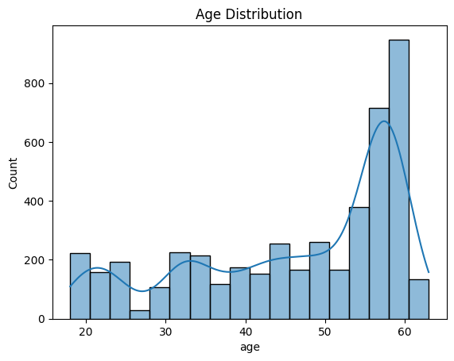

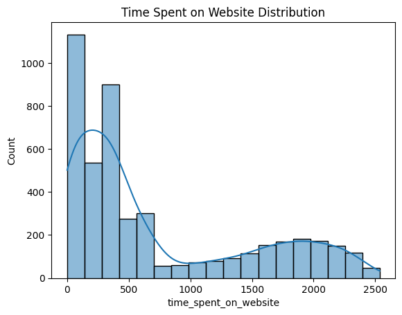

```python
import seaborn as sns
import matplotlib.pyplot as plt

# Plot histogram for 'age'
sns.histplot(data['age'], kde=True)
plt.title('Age Distribution')
plt.show()

# Plot distribution for 'time_spent_on_website'
sns.histplot(data['time_spent_on_website'], kde=True)
plt.title('Time Spent on Website Distribution')
plt.show()
```

By using Histograms , we can visualize the distribution of numerical features like age, website_visits, time_spent_on_website, etc.

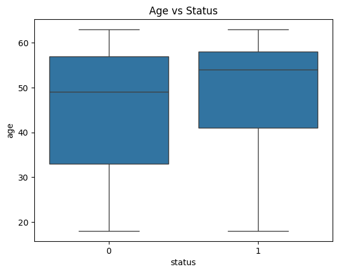

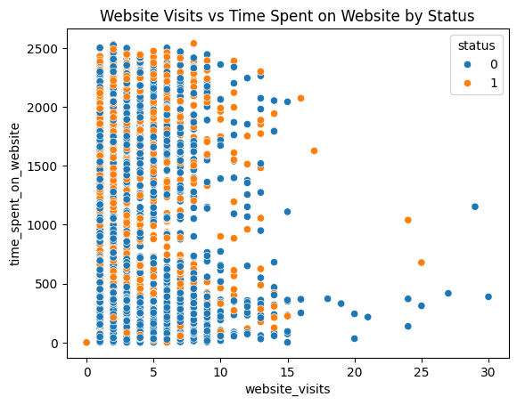

```python
# Boxplot of 'age' vs 'status'
sns.boxplot(x='status', y='age', data=data)
plt.title('Age vs Status')
plt.show()

# Scatter plot of 'website_visits' vs 'time_spent_on_website' colored by 'status'
sns.scatterplot(x='website_visits', y='time_spent_on_website', hue='status', data=data)
plt.title('Website Visits vs Time Spent on Website by Status')
plt.show()
```

Here , we check how numerical features (e.g., age, website_visits) impact the target variable (e.g., status).

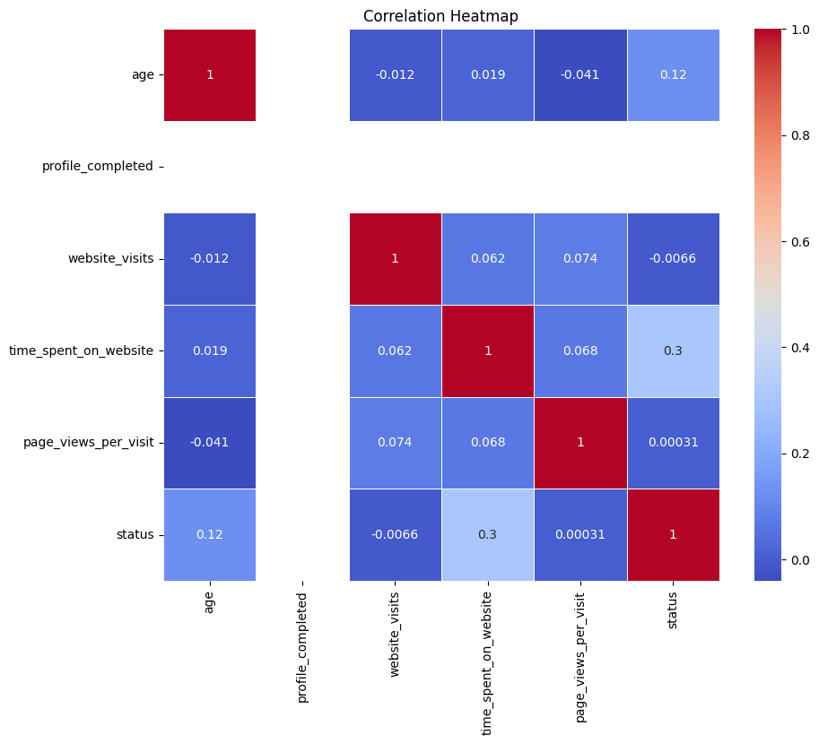

```python
# Drop non-numeric columns (e.g., 'ID', or any other irrelevant columns)
data = data.drop(columns=['ID'])

# Select only numeric columns
numeric_data = data.select_dtypes(include=['float64', 'int64'])

# Calculate the correlation matrix
corr_matrix = numeric_data.corr()

# Plot the correlation heatmap
plt.figure(figsize=(10, 8))
sns.heatmap(corr_matrix, annot=True, cmap='coolwarm', linewidths=0.5)
plt.title('Correlation Heatmap')
plt.show()
```

Checking the relationships between numerical features using a correlation matrix and heatmap.

## Building a Random Forest model

```python
print(data['first_interaction'].unique())
# Finding Categorical values in row 'first_interaction'
```

```
['Website' 'Mobile App']
```

```python
import pandas as pd

# Apply one-hot encoding to the 'first_interaction' column
data_encoded = pd.get_dummies(data, columns=['first_interaction'])

# Example: Apply one-hot encoding to binary columns
# One-Hot Encoding: For categorical columns with multiple categories (e.g., ['Yes', 'No']).
data_encoded = pd.get_dummies(data, columns=['print_media_type1', 'print_media_type2', 'digital_media', 'educational_channels', 'first_interaction'])
```

```python
print(data_encoded.columns)
# Checking the encoded columns
```

```
Index(['age', 'profile_completed', 'website_visits', 'time_spent_on_website',
       'page_views_per_visit', 'status', 'current_occupation_Professional',
       'current_occupation_Student', 'current_occupation_Unemployed',
       'last_activity_Email Activity', 'last_activity_Phone Activity',
       'last_activity_Website Activity', 'referral_No', 'referral_Yes',
       'age_group', 'print_media_type1_No', 'print_media_type1_Yes',
       'print_media_type2_No', 'print_media_type2_Yes', 'digital_media_No',
       'digital_media_Yes', 'educational_channels_No',
       'educational_channels_Yes', 'first_interaction_Mobile App',
       'first_interaction_Website'],
      dtype='object')
```

```python
print(data_encoded.dtypes)
# checking the data types of encoded columns to ensure , no categorical values exist
```

```
age                                   int64
profile_completed                     int64
website_visits                        int64
time_spent_on_website                 int64
page_views_per_visit                float64
status                                int64
current_occupation_Professional        bool
current_occupation_Student             bool
current_occupation_Unemployed          bool
last_activity_Email Activity           bool
last_activity_Phone Activity           bool
last_activity_Website Activity         bool
referral_No                            bool
referral_Yes                           bool
age_group                          category
print_media_type1_No                   bool
print_media_type1_Yes                  bool
print_media_type2_No                   bool
print_media_type2_Yes                  bool
digital_media_No                       bool
digital_media_Yes                      bool
educational_channels_No                bool
educational_channels_Yes               bool
first_interaction_Mobile App           bool
first_interaction_Website              bool
dtype: object
```

```python
# Drop the old 'first_interaction' column if it still exists
data_encoded = data_encoded.drop(columns=['first_interaction'], errors='ignore')
```

```python
print(data.dtypes)  # Check the data types of all columns
```

```
age                                   int64
first_interaction                    object
profile_completed                     int64
website_visits                        int64
time_spent_on_website                 int64
page_views_per_visit                float64
print_media_type1                    object
print_media_type2                    object
digital_media                        object
educational_channels                 object
status                                int64
current_occupation_Professional        bool
current_occupation_Student             bool
current_occupation_Unemployed          bool
last_activity_Email Activity           bool
last_activity_Phone Activity           bool
last_activity_Website Activity         bool
referral_No                            bool
referral_Yes                           bool
age_group                          category
dtype: object
```

```python
# Display unique values in potential problem columns
for col in data.columns:
    if data[col].dtype == 'object':
        print(f'{col}: {data[col].unique()}')
```

```
first_interaction: ['Website' 'Mobile App']
print_media_type1: ['Yes' 'No']
print_media_type2: ['No' 'Yes']
digital_media: ['Yes' 'No']
educational_channels: ['No' 'Yes']
```

```python
import pandas as pd

# Apply one-hot encoding to categorical columns
data_encoded = pd.get_dummies(data, columns=['first_interaction', 'print_media_type1', 'print_media_type2', 'digital_media', 'educational_channels'])
```

```python
# Label encoding
from sklearn.preprocessing import LabelEncoder

label_encoder = LabelEncoder()

# Apply label encoding to binary or categorical columns
for col in ['print_media_type1', 'print_media_type2', 'digital_media', 'educational_channels', 'first_interaction']:
    if data[col].dtype == 'object':
        data[col] = label_encoder.fit_transform(data[col])
```

```python
# Ensuring no columns are categorical & all are numerical
print(data_encoded.dtypes)
```

```
age                                   int64
profile_completed                     int64
website_visits                        int64
time_spent_on_website                 int64
page_views_per_visit                float64
status                                int64
current_occupation_Professional        bool
current_occupation_Student             bool
current_occupation_Unemployed          bool
last_activity_Email Activity           bool
last_activity_Phone Activity           bool
last_activity_Website Activity         bool
referral_No                            bool
referral_Yes                           bool
age_group                          category
first_interaction_Mobile App           bool
first_interaction_Website              bool
print_media_type1_No                   bool
print_media_type1_Yes                  bool
print_media_type2_No                   bool
print_media_type2_Yes                  bool
digital_media_No                       bool
digital_media_Yes                      bool
educational_channels_No                bool
educational_channels_Yes               bool
dtype: object
```

```python
# Checking numeric data
print(data_encoded.dtypes)
print(data_encoded.head())
```

```
age                                   int64
profile_completed                     int64
website_visits                        int64
time_spent_on_website                 int64
page_views_per_visit                float64
status                                int64
current_occupation_Professional        bool
current_occupation_Student             bool
current_occupation_Unemployed          bool
last_activity_Email Activity           bool
last_activity_Phone Activity           bool
last_activity_Website Activity         bool
referral_No                            bool
referral_Yes                           bool
age_group                          category
first_interaction_Mobile App           bool
first_interaction_Website              bool
print_media_type1_No                   bool
print_media_type1_Yes                  bool
print_media_type2_No                   bool
print_media_type2_Yes                  bool
digital_media_No                       bool
digital_media_Yes                      bool
educational_channels_No                bool
educational_channels_Yes               bool
dtype: object
   age  profile_completed  website_visits  time_spent_on_website  \
0   57                  0               7                   1639
1   56                  0               2                     83
2   52                  0               3                    330
3   53                  0               4                    464
4   23                  0               4                    600

   page_views_per_visit  status  current_occupation_Professional  \
0                 1.861       1                            False
1                 0.320       0                             True
2                 0.074       0                             True
3                 2.057       1                            False
4                16.914       0                            False

```

[output cut: 21 more lines]

```
  print_media_type2_No  print_media_type2_Yes  digital_media_No  \
0                 True                  False             False
1                 True                  False              True
2                 True                  False             False
3                 True                  False              True
4                 True                  False              True

   digital_media_Yes  educational_channels_No  educational_channels_Yes
0               True                     True                     False
1              False                    False                      True
2               True                     True                     False
3              False                     True                     False
4              False                     True                     False

[5 rows x 25 columns]
```

```python
# Preparing data for model training
from sklearn.model_selection import train_test_split

# Define features and target
X = data_encoded.drop(columns=['ID', 'status'], errors='ignore')  # Exclude 'ID' and target column
y = data_encoded['status']  # Target variable

# Split the data into training and testing sets
X_train, X_test, y_train, y_test = train_test_split(X, y, test_size=0.2, random_state=42)
```

```python
# Training the Random Forest Model
from sklearn.ensemble import RandomForestClassifier
from sklearn.metrics import accuracy_score, confusion_matrix, classification_report
from sklearn.preprocessing import OneHotEncoder

# Create a OneHotEncoder object
encoder = OneHotEncoder(handle_unknown='ignore')

# Fit the encoder on the training data
encoder.fit(X_train)

# Transform the training and testing data
X_train = encoder.transform(X_train)
X_test = encoder.transform(X_test)

# Create and train the Random Forest model
random_forest = RandomForestClassifier(n_estimators=100, random_state=42)
random_forest.fit(X_train, y_train)

# Make predictions and evaluate the model
y_pred = random_forest.predict(X_test)

accuracy = accuracy_score(y_test, y_pred)
print(f'Accuracy: {accuracy * 100:.2f}%')

conf_matrix = confusion_matrix(y_test, y_pred)
print('Confusion Matrix:')
print(conf_matrix)

class_report = classification_report(y_test, y_pred)
print('Classification Report:')
print(class_report)
```

```
Accuracy: 76.38%
Confusion Matrix:
[[566  83]
 [135 139]]
Classification Report:
              precision    recall  f1-score   support

           0       0.81      0.87      0.84       649
           1       0.63      0.51      0.56       274

    accuracy                           0.76       923
   macro avg       0.72      0.69      0.70       923
weighted avg       0.75      0.76      0.76       923
```

## Do we need to prune the tree?

Pruning is not always necessary, especially with Random Forests, but it can be useful when working with individual Decision Trees

## Actionable Insights and Recommendations

Insights:-

2.User Occupation: The largest group of users are Professionals (56.7%), followed by Unemployed individuals (31.2%) and Students (12%). The higher proportion of professionals may imply that targeting this group can yield better results for engagement.

Recommendation:-

2.Leverage Professionals:

With professionals forming the largest user base, creating tailored content or features for this group (e.g., career-related tools or content) may improve engagement.